[GitHub](https://github.com/agate-model/Agate.jl)[](https://github.com/agate-model/Agate.jl/blob/main/examples/allometric_relationships.jl)

# Allometric parameters

Many plankton traits depend on organism size (allometry). Agate uses this to calculate the parameter values of relevant parameters for each plankton size in the model.

We will first look at the default Agate.jl-Onyx relationship for maximum growth rate. We change only its exponent, compare the growth rates that Agate assigns to each phytoplankton size, and then run the two versions in the same simple box model. We then replace the built-in relationship with one based on [Ward et al. (2017)](https://doi.org/10.1086/689992) and repeat the same steps.

Info

The allometric relationships are defined with Agate. The short simulations later in the example use [Oceananigans.jl](https://clima.github.io/OceananigansDocumentation/stable/) and [OceanBioME.jl](https://oceanbiome.github.io/OceanBioME.jl/stable/) to run them in a box model.

## Loading dependencies

```julia
using Onyx
using Agate.Introspection: pfts
using Agate.Library.Allometry: AllometricParam, PowerLaw
using OceanBioME
using OceanBioME: Biogeochemistry
using Oceananigans
using Oceananigans.Fields: ConstantField
using Oceananigans.Units
using CairoMakie
```

## Choose the plankton sizes

We use five phytoplankton sizes so that the effect of size on growth is easy to see. The numbers below are cell diameters in μm. Here `P` is the phytoplankton PFT and `Z` is the zooplankton PFT. The chosen sizes also span the rise and fall in growth rate described by Ward et al. later in the example. In the box-model experiments, zooplankton starts at zero so that the first few days mainly show phytoplankton growth.

```julia
size_structure = (;
    phytoplankton=(P=[0.8, 2.0, 6.0, 20.0, 60.0],),
    zooplankton=(Z=[100.0],),
)
```

Onyx already uses Agate's built-in `PowerLaw` for `maximum_growth_rate`. A power law has the form `prefactor × V^exponent`, where `V` is spherical cell volume calculated from diameter. The prefactor sets the overall scale, while the exponent controls how strongly the value changes with size. Onyx's defaults are `2 / day` and `-0.15`. We write them explicitly here so that the change in the next section is easy to follow. `AllometricParam` combines the relationship with its coefficients so that it can be supplied as a model parameter.

```julia
default_growth = AllometricParam(
    PowerLaw();
    prefactor=2 / day,
    exponent=-0.15,
)
```

Pass the relationship through `parameters` when constructing Onyx. Agate then calculates the corresponding `maximum_growth_rate` for each plankton size.

```julia
default_bgc = Onyx.construct(;
    size_structure,
    parameters=(; maximum_growth_rate=default_growth),
)
```

The growth process applies only to phytoplankton, so its realized parameter storage contains exactly the phytoplankton SizeClasses.

```julia
phytoplankton_tracers = pfts(default_bgc).P
phytoplankton_diameters = size_structure.phytoplankton.P
default_growth_rates = default_bgc.parameters.maximum_growth_rate
```

## Change the built-in size relationship

An exponent closer to zero makes the decrease in growth rate with size weaker. Keep the default prefactor and change only the exponent from `-0.15` to `-0.05`. When the model is constructed, Agate evaluates this relationship for every phytoplankton size.

```julia
shallower_growth = AllometricParam(
    PowerLaw();
    prefactor=2 / day,
    exponent=-0.05,
)

shallower_bgc = Onyx.construct(;
    size_structure,
    parameters=(; maximum_growth_rate=shallower_growth),
)
shallower_growth_rates = shallower_bgc.parameters.maximum_growth_rate
```

### Compare the resulting growth rates

Before running a simulation, compare the values that the two relationships give each phytoplankton size:

`relationship + coefficients → construct → one parameter value for each SizeClass`.

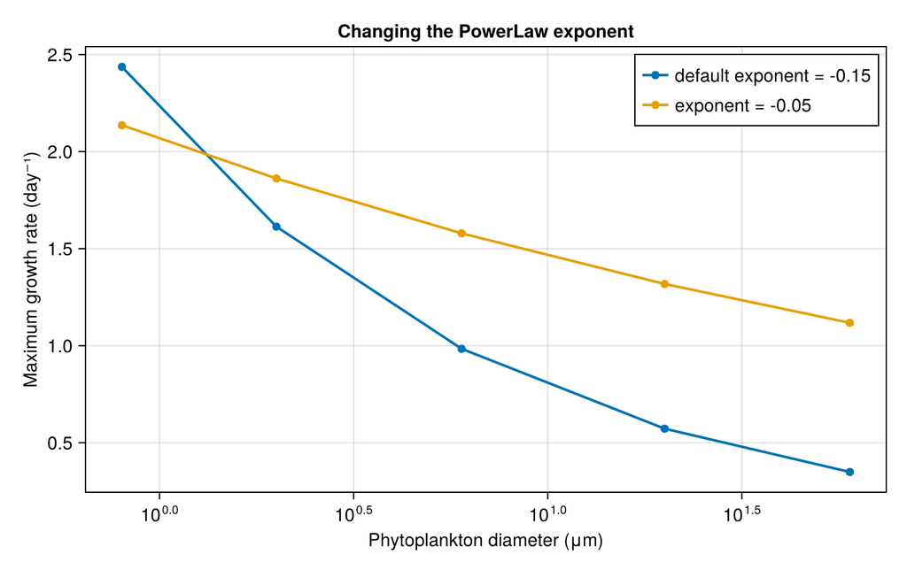

```julia
slope_fig = Figure(; size=(700, 440), fontsize=14)
slope_ax = Axis(
    slope_fig[1, 1];
    xlabel="Phytoplankton diameter (μm)",
    ylabel="Maximum growth rate (day⁻¹)",
    xscale=log10,
    title="Changing the PowerLaw exponent",
)

scatterlines!(
    slope_ax,
    phytoplankton_diameters,
    default_growth_rates .* day;
    label="default exponent = -0.15",
    linewidth=2,
)
scatterlines!(
    slope_ax,
    phytoplankton_diameters,
    shallower_growth_rates .* day;
    label="exponent = -0.05",
    linewidth=2,
)
axislegend(slope_ax; position=:rt)

slope_fig
```

### See the effect in a box model

Now run the default and modified relationships in the same well-mixed box model. The two simulations use the same light, nutrients, starting phytoplankton biomass, and initial zooplankton. This keeps the comparison focused on the change in maximum growth rate with size.

#### Run the simulations

First, set up and run a short box model for each constructed Agate model. The helper below saves the model fields every hour so we can inspect them afterwards.

```julia
function run_growth_experiment(bgc, phytoplankton_tracers, filename)
    grid = BoxModelGrid()
    light_attenuation = PrescribedPhotosyntheticallyActiveRadiation(ConstantField(100.0))
    bgc_model = Biogeochemistry(bgc; light_attenuation)
    model = BoxModel(; grid, biogeochemistry=bgc_model)

    phytoplankton_initial_conditions = (;
        (tracer => 0.01 for tracer in phytoplankton_tracers)...
    )
    initial_conditions = merge(
        (; N=20.0, D=0.0, Z_1=0.0),
        phytoplankton_initial_conditions,
    )
    set!(model; initial_conditions...)

    simulation = Simulation(model; Δt=60minutes, stop_time=3days)
    simulation.output_writers[:fields] = JLD2Writer(
        model,
        model.fields;
        filename,
        schedule=TimeInterval(1hour),
        overwrite_files=true,
    )

    run!(simulation)
    return filename
end

default_filename = run_growth_experiment(
    default_bgc,
    phytoplankton_tracers,
    "allometry_default_growth.jld2",
)
shallower_filename = run_growth_experiment(
    shallower_bgc,
    phytoplankton_tracers,
    "allometry_shallower_growth.jld2",
)
```

```
[ Info: Initializing simulation...
[ Info:     ... simulation initialization complete (2.079 seconds)
[ Info: Executing initial time step...
[ Info:     ... initial time step complete (890.348 ms).
[ Info: Simulation is stopping after running for 3.130 seconds.
[ Info: Simulation time 3 days equals or exceeds stop time 3 days.
[ Info: Initializing simulation...
[ Info:     ... simulation initialization complete (13.912 ms)
[ Info: Executing initial time step...
[ Info:     ... initial time step complete (1.466 ms).
[ Info: Simulation is stopping after running for 149.925 ms.
[ Info: Simulation time 3 days equals or exceeds stop time 3 days.
```

#### Load the results

Next, load the saved phytoplankton biomass through time for each simulation.

```julia
function load_growth_experiment(filename, phytoplankton_tracers)
    series = (;
        (tracer => FieldTimeSeries(filename, string(tracer))[1, 1, 1, :] for tracer in phytoplankton_tracers)...
    )
    times = FieldTimeSeries(filename, string(first(phytoplankton_tracers))).times
    return times, series
end

times, default_series = load_growth_experiment(default_filename, phytoplankton_tracers)
_, shallower_series = load_growth_experiment(shallower_filename, phytoplankton_tracers)
```

#### Plot the comparison

Finally, plot each phytoplankton SizeClass so the effect of the changed allometric slope can be compared through time.

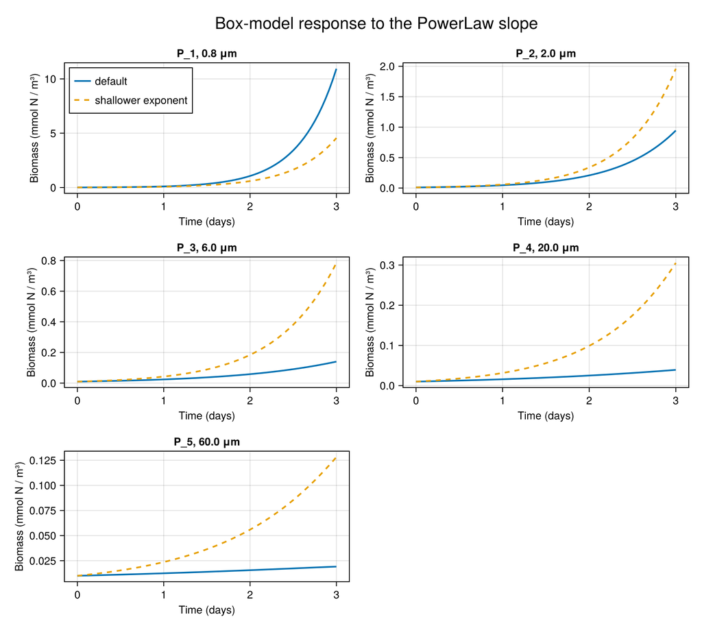

```julia
function plot_growth_comparison(
    times,
    reference_series,
    treatment_series,
    phytoplankton_tracers,
    phytoplankton_diameters;
    reference_label,
    treatment_label,
    title,
)
    fig = Figure(; size=(850, 760), fontsize=13)
    Label(fig[0, 1:2], title; fontsize=20)

    for (idx, (tracer, diameter)) in enumerate(zip(phytoplankton_tracers, phytoplankton_diameters))
        row = 1 + div(idx - 1, 2)
        col = 1 + mod(idx - 1, 2)
        ax = Axis(
            fig[row, col];
            xlabel="Time (days)",
            ylabel="Biomass (mmol N / m³)",
            title="$(tracer), $(diameter) μm",
        )

        lines!(
            ax,
            times / day,
            getproperty(reference_series, tracer);
            label=reference_label,
            linewidth=2,
        )
        lines!(
            ax,
            times / day,
            getproperty(treatment_series, tracer);
            label=treatment_label,
            linewidth=2,
            linestyle=:dash,
        )

        idx == 1 && axislegend(ax; position=:lt)
    end

    return fig
end

slope_box_fig = plot_growth_comparison(
    times,
    default_series,
    shallower_series,
    phytoplankton_tracers,
    phytoplankton_diameters;
    reference_label="default",
    treatment_label="shallower exponent",
    title="Box-model response to the PowerLaw slope",
)

slope_box_fig
```

## Use a custom relationship from Ward et al. (2017)

A single `PowerLaw` is useful when a parameter changes steadily with size. Published relationships can also have other shapes. With `AllometricParam`, we can provide our own rule for calculating a parameter from diameter and then use it in the same way.

Ward et al. (2017) describe maximum phytoplankton growth using three size-dependent quantities: maximum nitrogen uptake, $\rho_{max}$; the minimum cellular nitrogen requirement, $Q_{min}$; and the maximum metabolic growth rate, $\mu_\infty$. Their equation (3) combines them as

\[\mu_{max} = \frac{\mu_\infty \rho_{max}} {\mu_\infty Q_{min} + \rho_{max}}.\]

Ward et al. describe each of these quantities as a power law of cell volume, $V$. Here we use the adjusted coefficients from their table 1:

\[\rho_{max} = 0.024 V^{1.10}, \qquad Q_{min} = 0.032 V^{0.76}, \qquad \mu_\infty = 4.7 V^{-0.26}.\]

Here $V$ is cell volume in μm³. $\rho_{max}$ is in pg N cell⁻¹ day⁻¹, $Q_{min}$ is in pg N cell⁻¹, and $\mu_\infty$ is in day⁻¹. The nitrogen units cancel in equation (3), so the result is a growth rate. In the code below, rates given per day are divided by `day` so they use the same time units as the rest of the model.

A custom relationship is a function of `(coeffs, diameter)`, in that order. Agate supplies each plankton diameter, while the keyword arguments passed to `AllometricParam` below are available inside the function through `coeffs`.

```julia
function ward_maximum_growth(coeffs, diameter)
    volume = (4 / 3) * pi * (diameter / 2)^3

    rho_max = coeffs.rho_prefactor * volume^coeffs.rho_exponent
    q_min = coeffs.q_min_prefactor * volume^coeffs.q_min_exponent
    mu_infinity = coeffs.mu_infinity_prefactor * volume^coeffs.mu_infinity_exponent

    return mu_infinity * rho_max / (mu_infinity * q_min + rho_max)
end
```

```
ward_maximum_growth (generic function with 1 method)
```

Pair the Ward relationship with the coefficients from the paper.

```julia
ward_growth = AllometricParam(
    ward_maximum_growth;
    rho_prefactor=0.024 / day,
    rho_exponent=1.10,
    q_min_prefactor=0.032,
    q_min_exponent=0.76,
    mu_infinity_prefactor=4.7 / day,
    mu_infinity_exponent=-0.26,
)

ward_bgc = Onyx.construct(;
    size_structure,
    parameters=(; maximum_growth_rate=ward_growth),
)

ward_growth_rates = ward_bgc.parameters.maximum_growth_rate
```

### Compare the Ward relationship with the default

Agate's default relationship decreases steadily as phytoplankton get larger. The Ward relationship instead increases from the smallest cells to an intermediate-size maximum, then decreases again for larger cells.

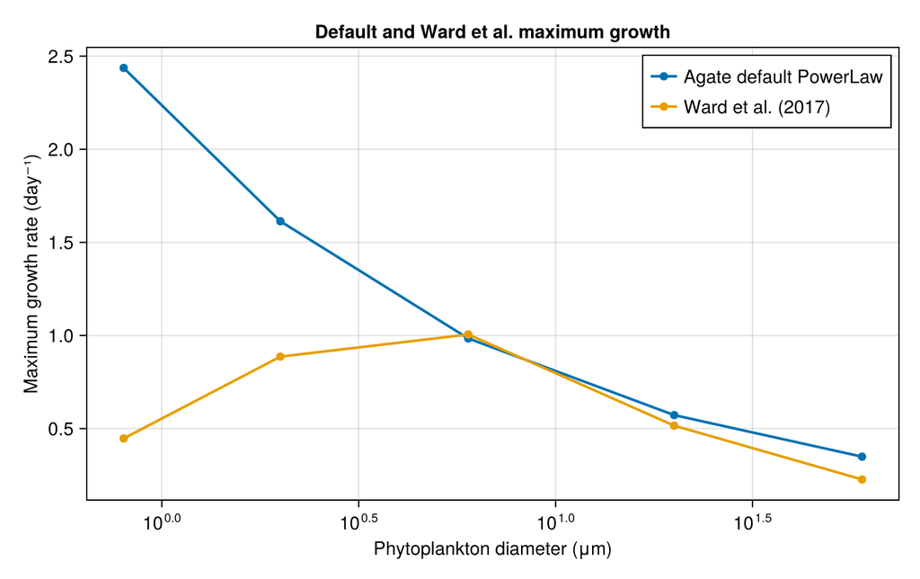

```julia
ward_fig = Figure(; size=(700, 440), fontsize=14)
ward_ax = Axis(
    ward_fig[1, 1];
    xlabel="Phytoplankton diameter (μm)",
    ylabel="Maximum growth rate (day⁻¹)",
    xscale=log10,
    title="Default and Ward et al. maximum growth",
)

scatterlines!(
    ward_ax,
    phytoplankton_diameters,
    default_growth_rates .* day;
    label="Agate default PowerLaw",
    linewidth=2,
)
scatterlines!(
    ward_ax,
    phytoplankton_diameters,
    ward_growth_rates .* day;
    label="Ward et al. (2017)",
    linewidth=2,
)
axislegend(ward_ax; position=:rt)

ward_fig
```

### See the effect in a box model

Finally, put the Ward relationship through the same run, load, and plot workflow. The environmental conditions and starting values are unchanged, so differences come from the relationship used for `maximum_growth_rate`.

#### Run the simulation

```julia
ward_filename = run_growth_experiment(
    ward_bgc,
    phytoplankton_tracers,
    "allometry_ward_growth.jld2",
)
```

```
[ Info: Initializing simulation...
[ Info:     ... simulation initialization complete (14.616 ms)
[ Info: Executing initial time step...
[ Info:     ... initial time step complete (1.537 ms).
[ Info: Simulation is stopping after running for 125.892 ms.
[ Info: Simulation time 3 days equals or exceeds stop time 3 days.
```

#### Load the results

```julia
_, ward_series = load_growth_experiment(ward_filename, phytoplankton_tracers)
```

#### Plot the comparison

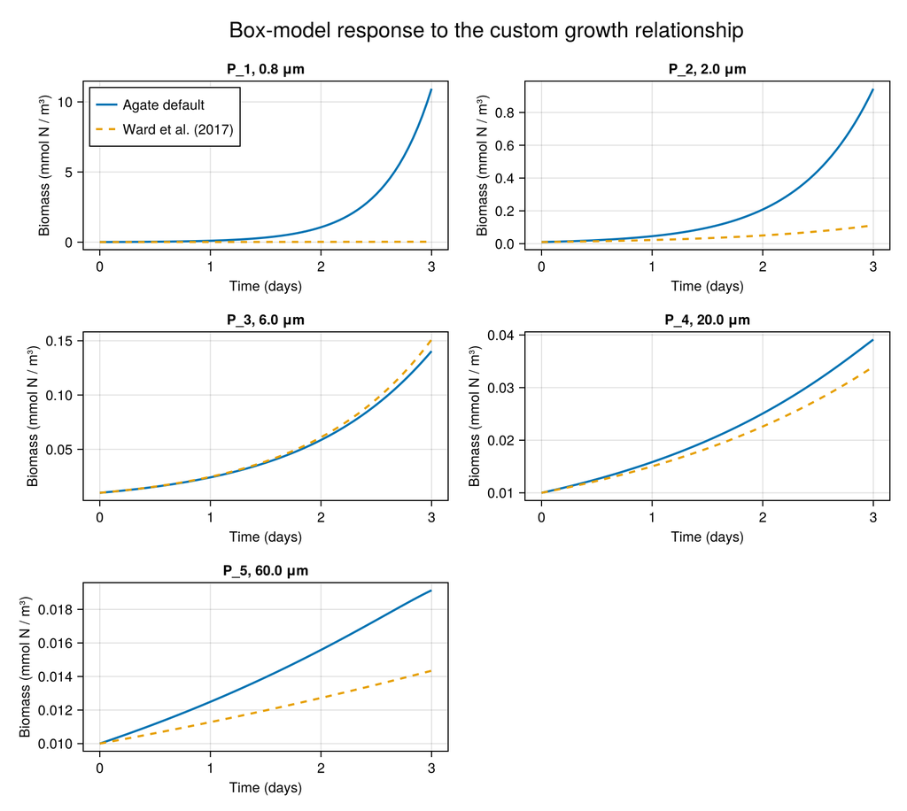

```julia
ward_box_fig = plot_growth_comparison(
    times,
    default_series,
    ward_series,
    phytoplankton_tracers,
    phytoplankton_diameters;
    reference_label="Agate default",
    treatment_label="Ward et al. (2017)",
    title="Box-model response to the custom growth relationship",
)

ward_box_fig
```

*This page was generated using Literate.jl.*